# Regression trees

06 May, 2022

## Classification & Regression Trees

## Classification & Regression Trees

### Advantanges

- Feature complexity
- **Prediction**
- Relative importance
- (Multi)collinearity

## Classification & Regression Trees

### Diss-advantanges

- over-fitting (over learning)

## Classification & Regression Trees

### Classification

- Categorical response

### Regression

- Continuous response

**CART**

## Simple regression trees

- split (**partition**) data up into **major** chunks

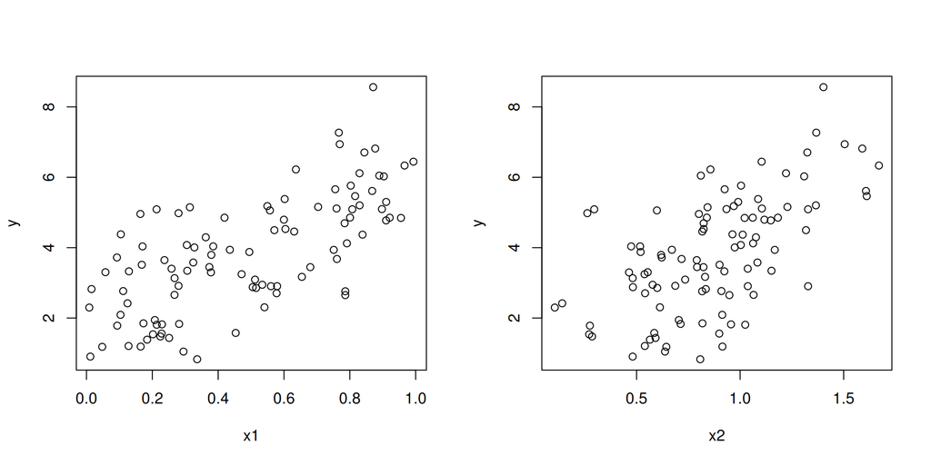

## Simple regression trees

- split (**partition**) data up into **major** chunks
  - maximizing change in explained deviance
  - when Gaussian error,
    - maximizing between group SS
    - minimizing SSerror

## Simple regression trees

[output not shown]

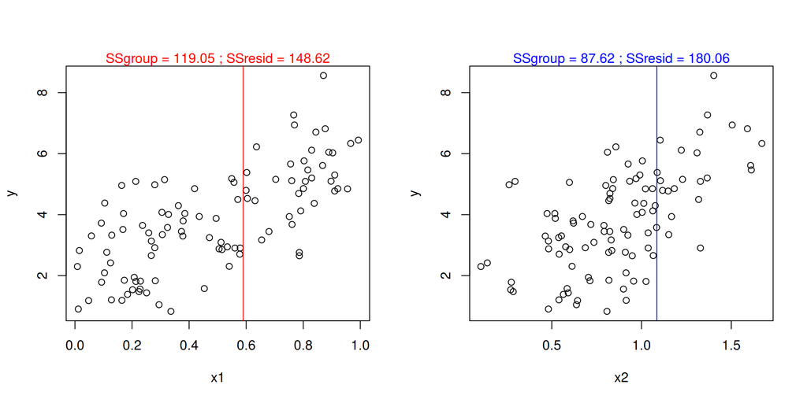

## Simple regression trees

- split (**partition**) data up into **major** chunks

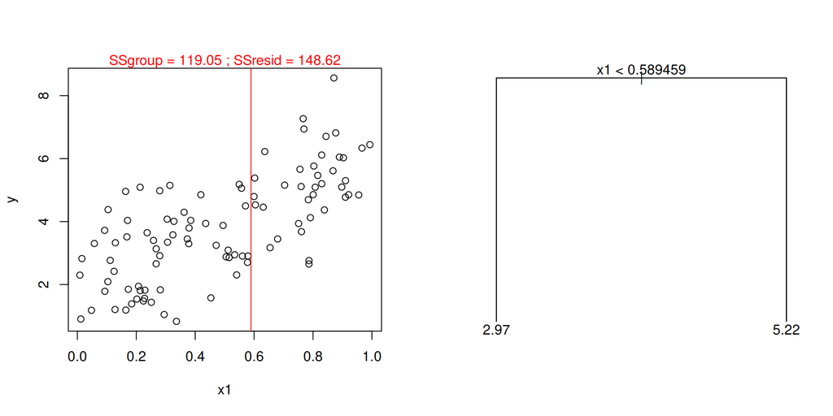

## Simple regression trees

- split (**partition**) data up into **major** chunks

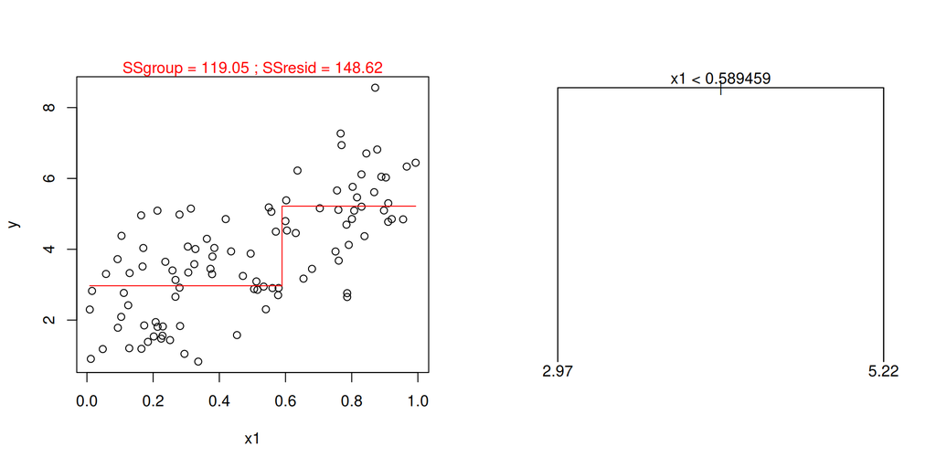

## Simple regression trees

- split these subsets

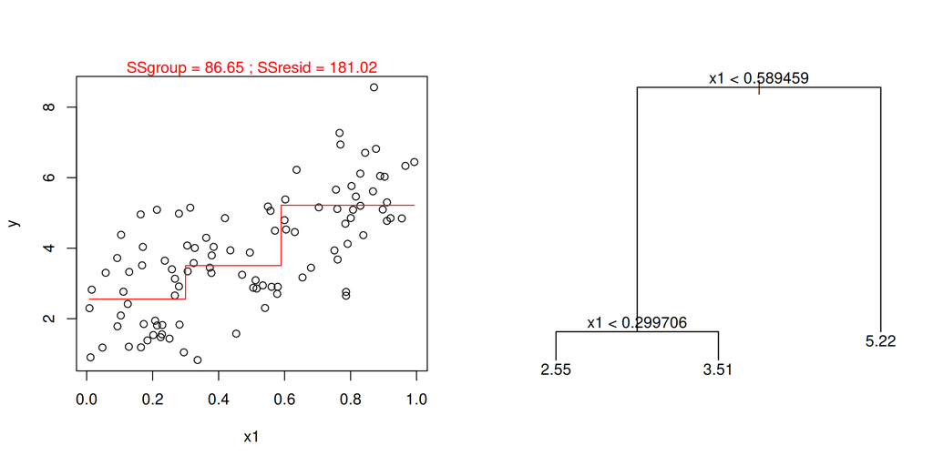

## Simple regression trees

- split these subsets

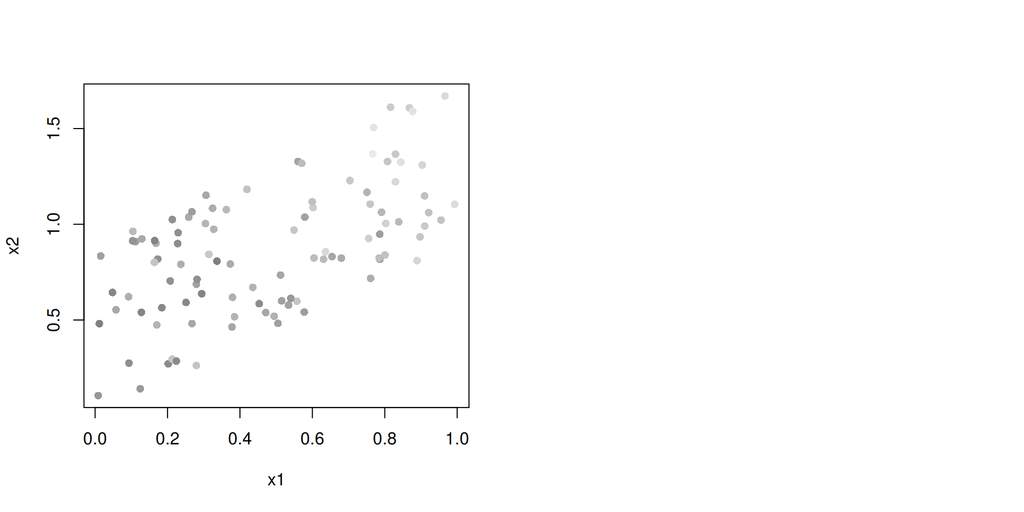

## Simple regression trees

- split these subsets

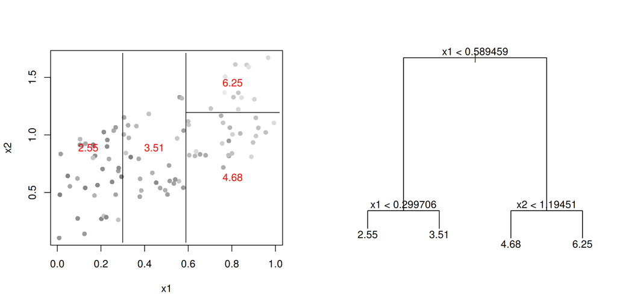

## Simple regression trees

- split these subsets

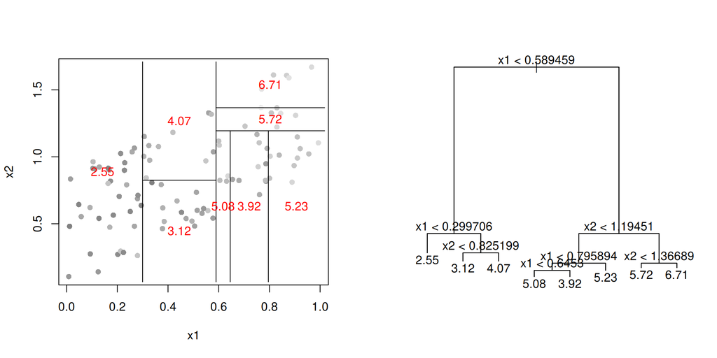

## Simple regression trees

- recursively partition (split)
- decision tree
- simple trees tend to overfit.
  - error is fitted along with the model

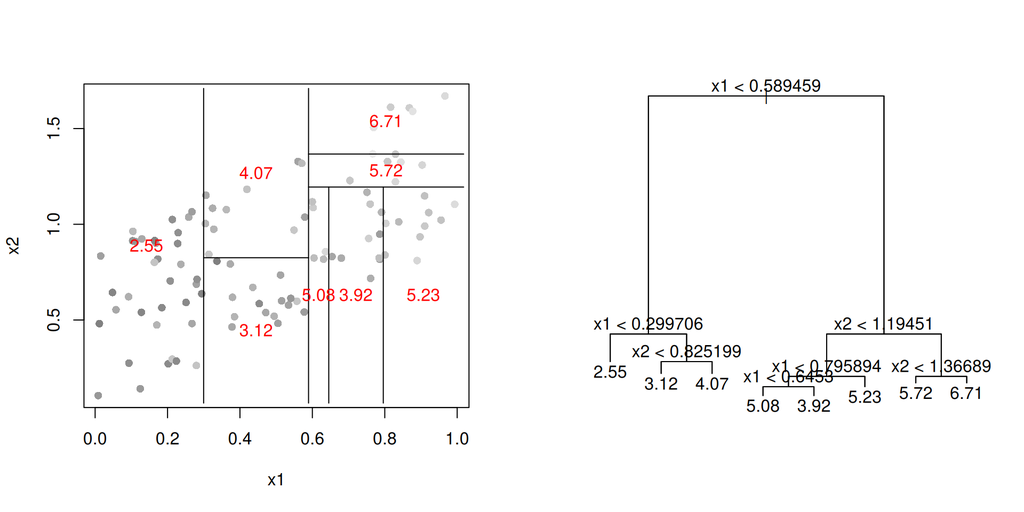

## Simple regression trees

### Pruning

- reduce overfitting
  - deviance at each terminal node (leaf)

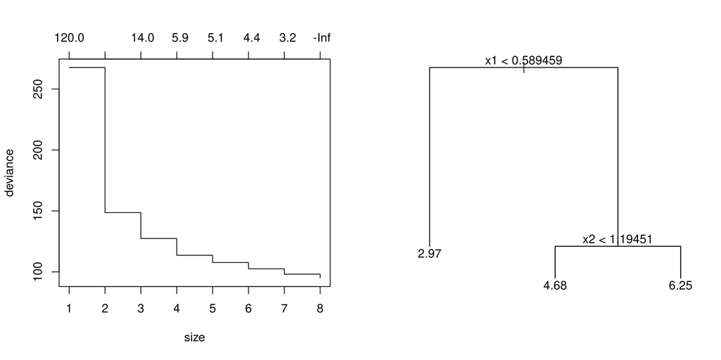

## Simple regression trees

### Predictions

- partial plots

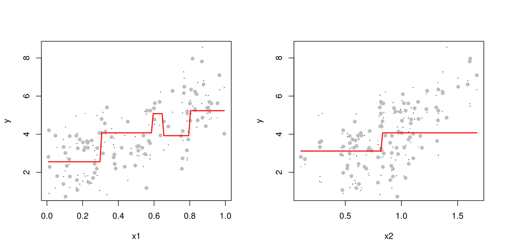

## Classification and Regression Trees

### R packages

- simple CART

```r
library(tree)
```

- an extension that facilitates (some) non-gaussian errors

```r
library(rpart)
```

## Classification and Regression Trees

### Limitations

- crude overfitting protection
- low resolution
- limited error distributions
- little scope for random effects

## Boosted regression Trees

### Boosting

- machine learning meets predictive modelling
- ensemble models
  - sequence of simple Trees (10,000+ trees)
  - built to predict residuals of previous tree
  - **shrinkage**
  - produce excellent fit

## Boosted regression Trees

### Over fitting

- over vs under fitting
- residual error vs precision
- minimizing square error loss

## Boosted regression Trees

### minimizing square error loss

- test (validation) data
  - 75% train, 25% test
- out of bag
  - 50% in, 50% out
- cross validation
  - 3 folds

## Boosted regression Trees

### Over fitting

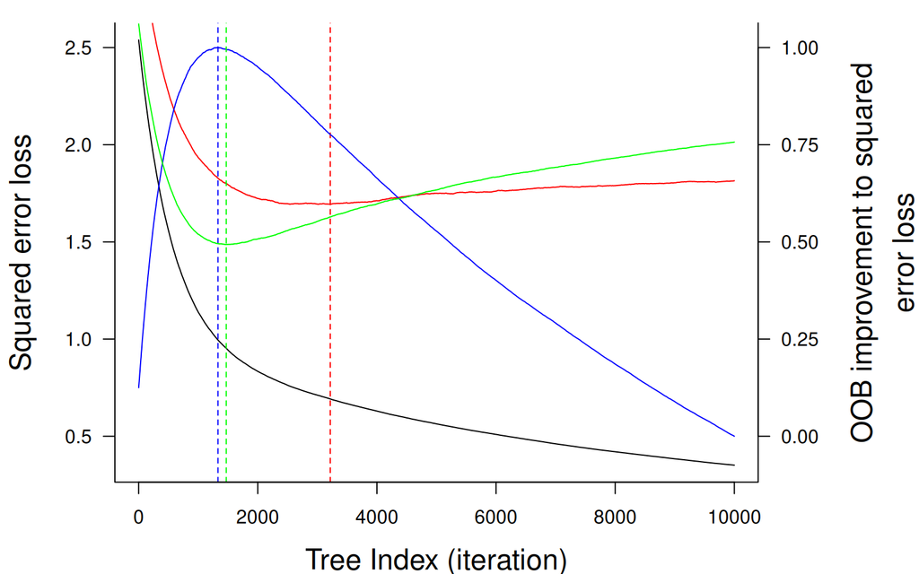

## Boosted regression Trees

### Predictions

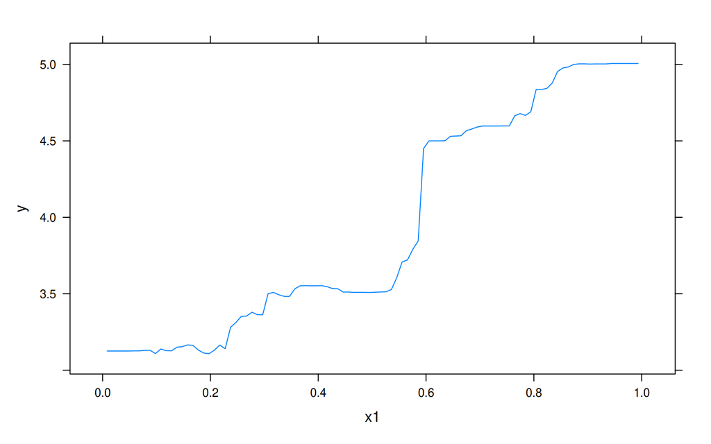

## Boosted regression Trees

### Variable importance

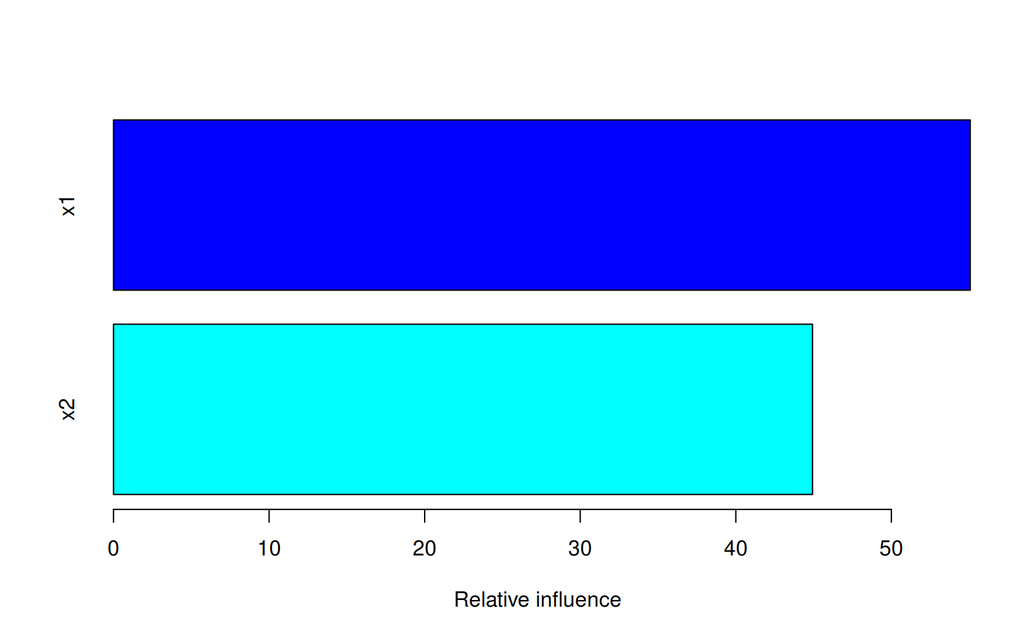

```
##    var  rel.inf
## x1  x1 55.06919
## x2  x2 44.93081
```

## Boosted regression Trees

### Pseudo \(R^2\)

\[ 1-\left(\frac{\sum (y_i - E(y))^2}{\sum(y_i - \bar{y})}\right) \]

```
## [1] 0.5650695
```